# JLC245 Project 2

Melanie Klein

2025-05-06

# Data

For the Fatal Force Database, The Washington Post collected and aggregated data on each police-involved shooting in the United States by manually gathering information from local news reports, law enforcement websites, social media, and independent databases. Each record includes details such as the location of the shooting, information about the victim, and data related to law enforcement. The dataset covers incidents from January 2, 2015, through December 31, 2024. A total of 10,428 police-involved shootings are recorded, with 1,131 cases missing location data. This dataset is more comprehensive than those maintained by the FBI and CDC which track fatal police shootings. Additional metadata and documentation are available on the GitHub repository where the dataset is published.

# Methods

To better understand police-involved shootings in the United States, events from the Fatal Force database were analyzed. The data was first summarized at the national level across multiple features, including year, race, mental illness, weapon type armed with, and body camera usage. The same variables were then used to summarize data at the city level. National-level patterns were compared to trends in Washington, D.C. to assess alignment. Finally, city-level data was visualized to identify other cities with patterns similar to those observed in Washington, D.C.

## City 1: San Bernardino, CA

San Bernardino, CA is similar to Washington, D.C. based on the attributes of the total number of police-involved killings and the type of weapon the person was armed with. Specifically, for the total number of police-involved killings, 30 police-involved killings have occurred in San Bernardino, CA, which is equal to the 30 police-involved killings that have occurred in Washington, D.C. Each city makes up 0.29% of the total number of police-involved killings in the United States. Specifically, for the type of weapon the person was armed with, 56.67% of police-involved killings in San Bernardino, CA had a person armed with a gun, which is equal to the 56.67% of police-involved killings in Washington, D.C. that had a person armed with a gun. Both cities had 17 people armed with a gun who were in a police-involved killing.

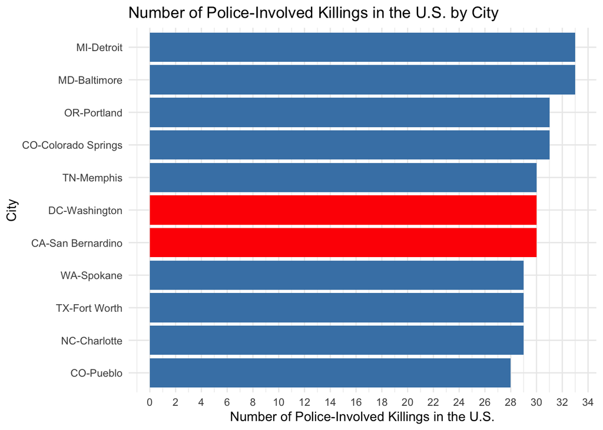

## City 2: Sacramento, CA

Sacramento, CA is similar to Washington, D.C. based on the attributes of the total number of police-involved killings and whether the police officer wore a body camera. Specifically, for the total number of police-involved killings, 27 police-involved killings have occurred in Sacramento, CA which is only 3 less than the 30 police-involved killings that have occurred in Washington, D.C. Sacramento, CA makes up 0.26% and Washington, D.C makes up 0.29% of the total number of police-involved killings in the United States. Specifically, for whether the police officer wore a body camera, 48.15% of police-involved killings in Sacramento, CA had a police officer wearing a body camera which is only 1.48% greater than the 46.67% of police-involved killings in Washington, D.C. that had a police officer wearing a body camera. Sacramento, CA had 13 instances and Washington, D.C. had 14 instances of police-involved killings that had a police officer wearing a body camera.

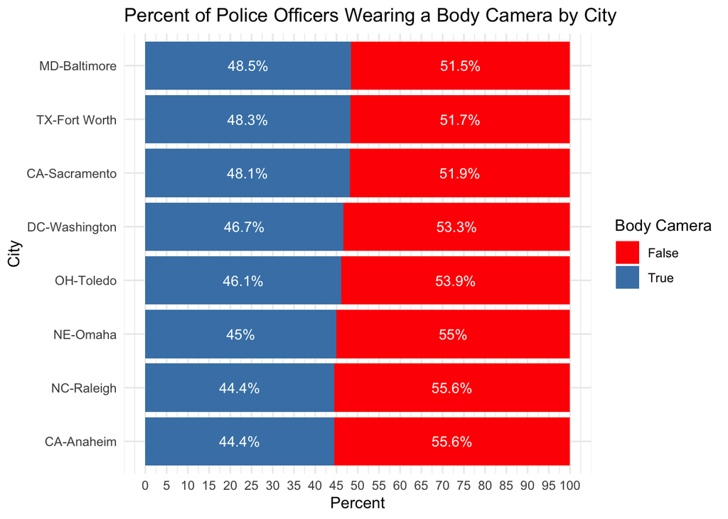

## City 3: Baltimore, MD

Baltimore, MD is similar to Washington, D.C. based on the attributes of whether the police officer wore a body camera and the race of the person. Specifically, for whether the police officer wore a body camera, 48.48% of police-involved killings in Baltimore, MD had a police officer wearing a body camera which is only 1.81% greater than the 46.67% of police-involved killings in Washington, D.C. that had a police officer wearing a body camera. Baltimore, MD had 16 instances and Washington, D.C. had 14 instances of police-involved killings that had a police officer wearing a body camera. Specifically, for the race of the person, 96.97% of police-involved killings in Baltimore, MD were of a Black person which is only 6.97% greater than the 90% of police-involved killings in Washington, DC that were of a Black person. Baltimore, MD had 32 people and Washington, DC had 27 people who were Black and in a police-involved killing.

[figure not shown]

## City 4: San Francisco, CA

San Francisco, CA is similar to Washington, D.C. based on the attributes of the total number of police-involved killings and the yearly trend of police-involved killings from 2015 to 2024. Specifically, for the total number of police-involved killings, 26 police-involved killings have occurred in San Francisco, CA which is only 4 less than the 30 police-involved killings that have occurred in Washington, D.C. San Francisco, CA makes up 0.25% and Washington, D.C makes up 0.29% of the total number of police-involved killings in the United States. Specifically, for the yearly trend of police-involved killings from 2015 to 2024, both San Francisco, CA and Washington, D.C have relatively decreased and then increased over time, still having fewer police-involved killings in 2024 than in 2015. In the past three years, both cities have had the same number of police-involved killings: 3 in 2022, 4 in 2023, and 2 in 2024.

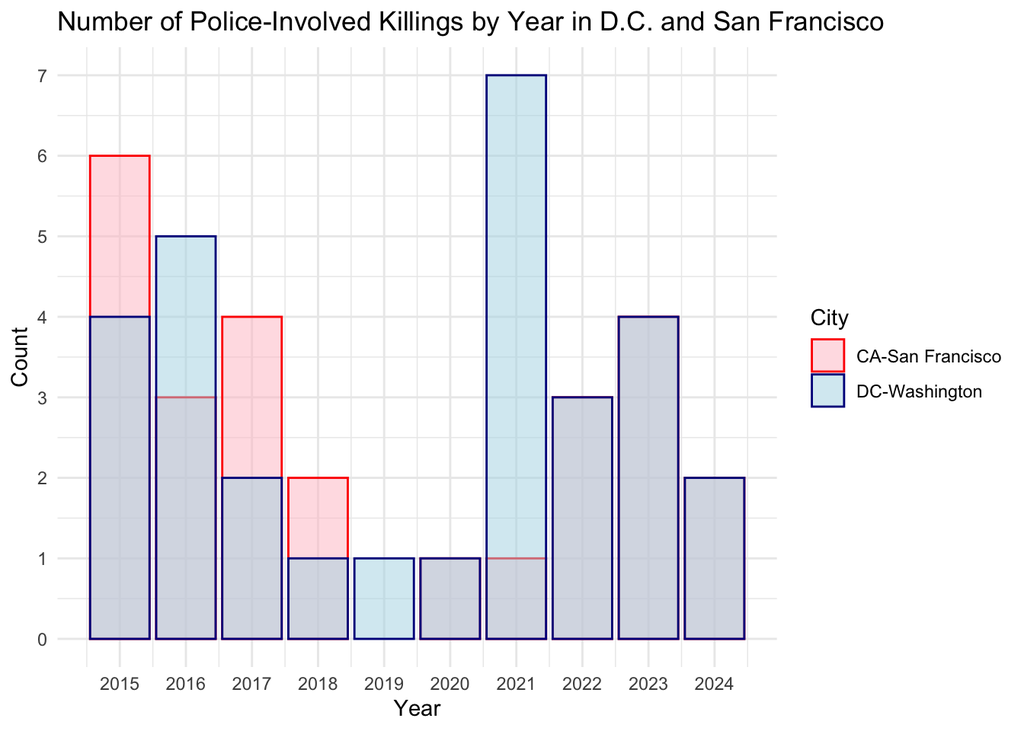

## City 5: Atlanta, GA

Atlanta, GA is similar to Washington, D.C. based on the attributes of the type of weapon the person was armed with and whether the person was experiencing a mental health crisis. Specifically, for the type of weapon the person was armed with, 56.41% of police-involved killings in Atlanta, GA had a person armed with a gun, which is only 0.26% less than the 56.67% of police-involved shootings in Washington, D.C. that had a person armed with a gun. Atlanta, GA had 22 people and Washington, D.C. had 17 people armed with a gun who were in a police-involved killing. Specifically, for whether the person was experiencing a mental health crisis, 15.38% of police-involved killings in Atlanta, GA had a person experiencing a mental health crisis which is only 1.29% less than the 16.67% of police-involved killings in Washington, DC that had a person experiencing a mental health crisis. Atlanta, GA had 6 people and Washington, D.C. had 5 people experiencing a mental health crisis who were in a police-involved killing.

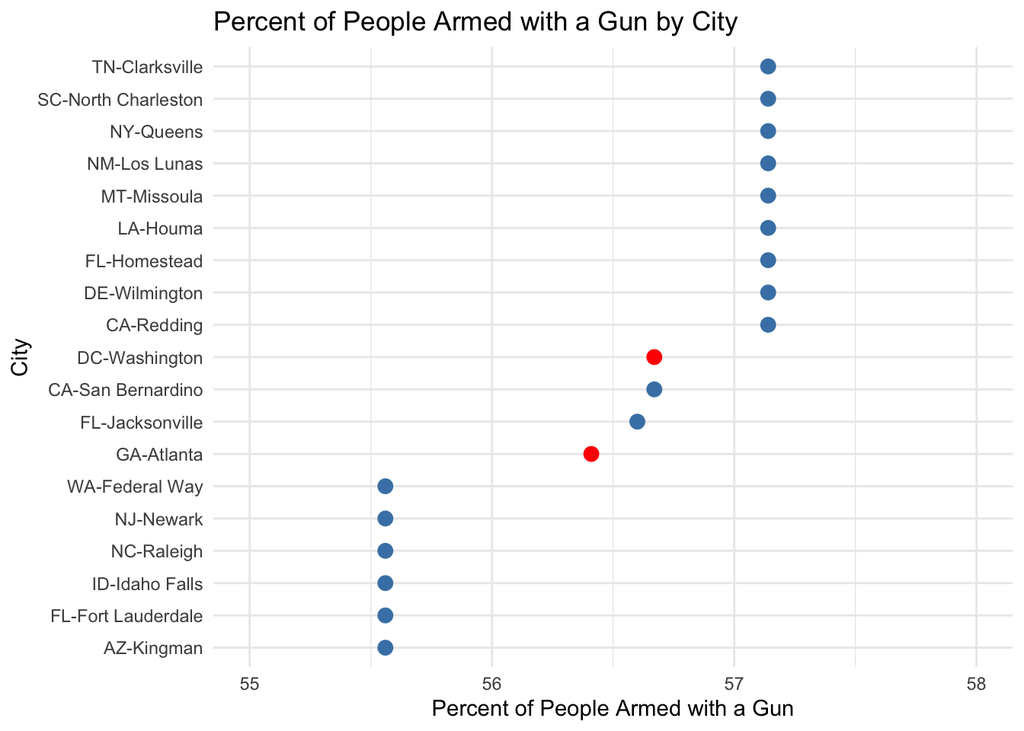